# Report - 2020-04-08

```python
%matplotlib inline
import pandas as pd
import geopandas as gpd
import numpy as np
import datetime
import matplotlib.pyplot as plt
import matplotlib
import json
import plotly.graph_objects as go
import plotly.express as px
from plotly.subplots import make_subplots
import os
from scipy.optimize import curve_fit
from scipy.interpolate import interp1d
font = {'family' : 'Linux Biolinum',
        'weight' : 'bold',
        'size'   : 22}

matplotlib.rc('font', **font)
path_to_geojson = "geo-data-hungary/GeoJSON/"
```

## Statistical data used for the analysis

- **Population of Hungary:** 9 769 012
  - *Hungarian Statistical Office*
- **Ventilators / 100 000 People:** 22.8
  - *https://hu.euronews.com/2020/03/20/csaknem-ketszaz-lelegeztetogep-erkezik-kinabol-a-kovetkezo-napokban*

```python
population = 9769012
ventilators = 1e-5 * population * 22.8
ratio_of_ventilator_use = 0.032
```

## Description of the dataset

- **Origin of data**: https://koronavirus.gov.hu
- **Structure:**
  - **Date:** the date when the given data has been published
  - **Active:** registered active cases at the time of the publication of the data
  - **Deaths:** death cases accounted to COVID-19
  - **Recovered:** number of cases when an active case recovered
  - **New:** new cases compared to previous data publishing
  - **DailyRate:** the number of new cases on a given day divided by the previous day's

```python
df = pd.read_csv("dataset/koronavirus.gov.hu.csv")
df
```

|  | Date | Active | Deaths | Recovered | New | DailyRate |
| --- | --- | --- | --- | --- | --- | --- |
| 0 | 2020-03-04 | 2 | 0 | 0 | 2 | NaN |
| 1 | 2020-03-05 | 4 | 0 | 0 | 2 | 1.000000 |
| 2 | 2020-03-06 | 4 | 0 | 0 | 0 | 0.000000 |
| 3 | 2020-03-07 | 5 | 0 | 0 | 1 | NaN |
| 4 | 2020-03-08 | 7 | 0 | 0 | 2 | 2.000000 |
| 5 | 2020-03-09 | 9 | 0 | 0 | 2 | 1.000000 |
| 6 | 2020-03-10 | 12 | 0 | 0 | 3 | 1.500000 |
| 7 | 2020-03-11 | 13 | 0 | 0 | 1 | 0.333333 |
| 8 | 2020-03-12 | 15 | 0 | 1 | 3 | 3.000000 |
| 9 | 2020-03-13 | 18 | 0 | 1 | 3 | 1.000000 |
| 10 | 2020-03-14 | 29 | 0 | 1 | 11 | 3.666667 |
| 11 | 2020-03-15 | 30 | 1 | 1 | 2 | 0.181818 |
| 12 | 2020-03-16 | 36 | 1 | 2 | 7 | 3.500000 |
| 13 | 2020-03-17 | 47 | 1 | 2 | 11 | 1.571429 |
| 14 | 2020-03-18 | 55 | 1 | 2 | 8 | 0.727273 |
| 15 | 2020-03-19 | 70 | 1 | 2 | 15 | 1.875000 |
| 16 | 2020-03-20 | 74 | 4 | 7 | 12 | 0.800000 |
| 17 | 2020-03-21 | 92 | 4 | 7 | 18 | 1.500000 |
| 18 | 2020-03-22 | 109 | 6 | 16 | 28 | 1.555556 |
| 19 | 2020-03-23 | 138 | 8 | 21 | 36 | 1.285714 |
| 20 | 2020-03-24 | 157 | 9 | 21 | 20 | 0.555556 |
| 21 | 2020-03-25 | 195 | 10 | 21 | 39 | 1.950000 |
| 22 | 2020-03-26 | 223 | 10 | 28 | 35 | 0.897436 |
| 23 | 2020-03-27 | 256 | 10 | 34 | 39 | 1.114286 |
| 24 | 2020-03-28 | 298 | 11 | 34 | 43 | 1.102564 |
| 25 | 2020-03-29 | 361 | 13 | 34 | 65 | 1.511628 |
| 26 | 2020-03-30 | 398 | 15 | 34 | 39 | 0.600000 |
| 27 | 2020-03-31 | 439 | 16 | 37 | 45 | 1.153846 |
| 28 | 2020-04-01 | 465 | 20 | 40 | 33 | 0.733333 |
| 29 | 2020-04-02 | 522 | 21 | 42 | 57 | 1.727273 |
| 30 | 2020-04-03 | 554 | 26 | 43 | 32 | 0.561404 |
| 31 | 2020-04-04 | 588 | 32 | 58 | 55 | 1.718750 |
| 32 | 2020-04-05 | 633 | 34 | 66 | 55 | 1.000000 |
| 33 | 2020-04-06 | 639 | 38 | 67 | 6 | 0.109091 |
| 34 | 2020-04-07 | 699 | 47 | 71 | 60 | 10.000000 |
| 35 | 2020-04-08 | 743 | 58 | 94 | 44 | 0.733333 |

## Used model functions

### Exponential function

- Formula: $f(x)=A\cdot\beta^x$
- Interpretation: Let's say that we have initially $A$ people who by average create $A\cdot\beta$ new cases per day. If this rate is not changing the data follows a strict exponential. In reality there is a change in $\beta$ because of the different interventions hence the following would be more appropiate:
  - $f(x)=A\cdot\beta^x(x)$
- Problems of the model:
  - An approximation is needed for $\beta(x)$
  - It is not true that all the infections originate from the initial $A$ since movement between borders were possible and still is for certain cases
- Advantages:
  - $\beta$ can hide severeal unknown parameters so we can call $A$ and $\beta(x)$ as effective parameters

```python
def exponentialFunction(x, beta, A):
    return A*np.power(beta, x)
```

## Statistics

### Active cases

```python
def activeCasesPlot(ylog=False):
    fig = go.Figure()

    fig.add_trace(go.Scatter(x=df["Date"],
                             y=df["Active"],
                             mode='lines+markers',
                             name='Active cases',
                             line_shape="spline",
                             line=dict(width=2,
                                      color="dodgerblue"),
                             marker=dict(size=10),)
                 )

    fig.update_layout(
        title="Active cases in Hungary, total active cases today: %d" % df["Active"].iloc[-1],
        xaxis_title="Date of observation",
        yaxis_title="Number of active cases",
        font=dict(
            family="Linux Biolinum",
            size=18,
        )
    )

    if ylog:
        fig.update_layout(
            yaxis_type="log",
        )

    fig.show()
```

```python
activeCasesPlot()
```

[interactive chart not shown]

```python
def dailyNewCasesPlot(ylog=False):
    fig = go.Figure()
    fig.add_trace(go.Scatter(x=df["Date"],
                             y=df["New"],
                             mode='lines+markers',
                             name='Daily new cases',
                             line_shape="spline",
                             line=dict(width=2,
                                      color="dodgerblue"),
                             marker=dict(size=10),)
                 )

    fig.update_layout(
        title="Daily new cases in Hungary, today: %d" % df["New"].iloc[-1],
        xaxis_title="Date of observation",
        yaxis_title="Number of daily new cases",
        font=dict(
            family="Linux Biolinum",
            size=18,
        )
    )

    if ylog:
        fig.update_layout(
            yaxis_type="log",
        )

    fig.show()
```

```python
dailyNewCasesPlot()
```

[interactive chart not shown]

```python
def dailyNewCasesRatioPlot(ylog=False):
    fig = go.Figure()
    fig.add_trace(go.Scatter(x=df["Date"],
                             y=df["DailyRate"],
                             mode='lines+markers',
                             name='Ratio of daily new cases compared to previous day',
                             line_shape="spline",
                             line=dict(width=2,
                                      color="dodgerblue"),
                             marker=dict(size=10),)
                 )

    fig.update_layout(
        title="Ratio of daily new cases compared to previous day in Hungary, average: %.2f" % df["DailyRate"].mean(),
        xaxis_title="Date of observation",
        yaxis_title="Ratio of daily new cases",
        font=dict(
            family="Linux Biolinum",
            size=18,
        )
    )

    if ylog:
        fig.update_layout(
            yaxis_type="log",
        )

    fig.show()
```

```python
dailyNewCasesRatioPlot()
```

[interactive chart not shown]

### Deaths

```python
def deathCasesPlot(ylog=False):
    fig = go.Figure()

    fig.add_trace(go.Bar(
        x=df["Date"],
        y=df["Deaths"].diff(),
        name="Daily death cases",
        marker=dict(
            color="tomato",
        )
    ))

    fig.add_trace(go.Scatter(x=df["Date"],
                             y=df["Deaths"],
                             mode='lines+markers',
                             name='Death cases',
                             line_shape="spline",
                             line=dict(width=2,
                                       color='firebrick',
                                      ),
                             marker=dict(size=10),)
                 )

    fig.update_layout(
        title="Death cases in Hungary, total: %d" % df["Deaths"].iloc[-1],
        xaxis_title="Date of observation",
        yaxis_title="Number of death cases",
        font=dict(
            family="Linux Biolinum",
            size=18,
        )
    )

    if ylog:
        fig.update_layout(
            yaxis_type="log",
        )

    fig.show()
```

```python
deathCasesPlot()
```

[interactive chart not shown]

### Recovery

```python
def recoveredCasesPlot(ylog=False):
    fig = go.Figure()

    fig.add_trace(go.Bar(
        x=df["Date"],
        y=df["Recovered"].diff(),
        name="Daily recovered cases",
        marker=dict(
            color="chartreuse",
        )
    ))

    fig.add_trace(go.Scatter(x=df["Date"],
                             y=df["Recovered"],
                             mode='lines+markers',
                             name='Recovered cases',
                             line_shape="spline",
                             line=dict(width=2,
                                       color='seagreen',
                                      ),
                             marker=dict(size=10),)
                 )

    fig.update_layout(
        title="Recovered cases in Hungary, total: %d" % df["Recovered"].iloc[-1],
        xaxis_title="Date of observation",
        yaxis_title="Number of recovered cases",
        font=dict(
            family="Linux Biolinum",
            size=18,
        )
    )

    if ylog:
        fig.update_layout(
            yaxis_type="log",
        )

    fig.show()
```

```python
recoveredCasesPlot()
```

[interactive chart not shown]

### Combined data

```python
def combinedCasesPlot(ylog=False):
    fig = go.Figure()



    fig.add_trace(go.Bar(
        x=df["Date"],
        y=df["Deaths"],
        name='Death cases',
        marker=dict(
            color="tomato"),
    ))

    fig.add_trace(go.Bar(
        x=df["Date"],
        y=df["Recovered"],
        name="Recovered cases",
        marker=dict(
            color="chartreuse",
        )
    ))

    fig.add_trace(go.Bar(
        x=df["Date"],
        y=df["Active"],
        name='Active cases',
        marker=dict(
            color="dodgerblue"),
    ))

    fig.update_layout(
        title="Current situation in Hungary",
        barmode="stack",
        xaxis_title="Date of observation",
        yaxis_title="Number of cases",
        font=dict(
            family="Linux Biolinum",
            size=18,
        )
    )

    if ylog:
        fig.update_layout(
            yaxis_type="log",
        )

    fig.show()
```

```python
combinedCasesPlot()
```

[interactive chart not shown]

```python
def dailyCombinedCasesPlot(ylog=False):
    fig = go.Figure()

    fig.add_trace(go.Bar(
        x=df["Date"],
        y=df["Deaths"].diff(),
        name='Daily death cases',
        marker=dict(
            color="tomato"),
    ))

    fig.add_trace(go.Bar(
        x=df["Date"],
        y=df["Recovered"].diff(),
        name="Daily recovered cases",
        marker=dict(
            color="chartreuse",
        )
    ))

    fig.add_trace(go.Bar(
        x=df["Date"],
        y=df["Active"].diff(),
        name='Daily new active cases',
        marker=dict(
            color="dodgerblue"),
    ))

    fig.update_layout(
        title="Current situation in Hungary",
        barmode="stack",
        xaxis_title="Date of observation",
        yaxis_title="Number of daily new cases",
        font=dict(
            family="Linux Biolinum",
            size=18,
        )
    )

    if ylog:
        fig.update_layout(
            yaxis_type="log",
        )

    fig.show()
```

```python
dailyCombinedCasesPlot()
```

[interactive chart not shown]

## Fitting models

- In my model I assume that we can see changes in $\beta$ from time to time because of:
  - Introduced policies
  - Events around the world
- The change is "almost instant" so it happens in 1-2 days
- **Note:** Since the virus responsible for COVID-19 is often not producing symptoms till the 14th day, while the person is infectious, there is a delay in the applied policies.

```python
# By index, selected manually
divider_points = [0, 5, 15, 25]

# Extrapolation till this day from 2020-03-04
day_limit = 50

popts = []
pcovs = []
ranges = []
evaluated_fits = []

for i in range(len(divider_points)-1):
    ranges.append(df.index[divider_points[i]:divider_points[i+1]])
    popt, pcov = curve_fit(exponentialFunction,
                           ranges[-1],
                           df["Active"].iloc[divider_points[i]:divider_points[i+1]])
    popts.append(popt)
    pcovs.append(pcov)
    evaluated_fits.append(exponentialFunction(ranges[-1], *popts[-1]))

ranges.append(df.index[divider_points[-1]:])
popt, pcov = curve_fit(exponentialFunction,
                       ranges[-1],
                       df["Active"].iloc[divider_points[-1]:])
popts.append(popt)
pcovs.append(pcov)
evaluated_fits.append(exponentialFunction(ranges[-1], *popts[-1]))

extra_range = range(df.index[-1]+1, day_limit)
extra_y = exponentialFunction(extra_range, *popts[-1])

base = df["Date"].iloc[0]
date_list = [datetime.datetime.strptime(base, "%Y-%m-%d") + datetime.timedelta(days=x) for x in range(day_limit)]

fig = go.Figure()



fig.add_trace(go.Scatter(
    x=date_list,
    y=np.hstack((
        np.hstack(evaluated_fits),
        extra_y
    )),
    name="Model",
    line=dict(
        width=2,
    )
))

fig.add_trace(go.Scatter(x=df["Date"],
                         y=df["Active"],
                         mode='markers',
                         name='Data',
                         marker=dict(
                             size=10,
                         )
                        ))

betas = []
for i in popts:
    betas.append("%.2f" % i[0])

fig.add_trace(go.Scatter(
    x=df["Date"].iloc[divider_points],
    y=df["Active"].iloc[divider_points],
    text=betas,
    textposition="top center",
    mode="markers+text",
    name=r"New $\beta$ value",
    marker=dict(
        size=15,
        color="rgba(0, 0, 0, 0.4)"
    )
))

for j,i in enumerate(popts[:-1]):
    fig.add_trace(go.Scatter(
        x=date_list[divider_points[j]:],
        y=exponentialFunction(range(divider_points[j], day_limit), *i),
        name=r"%.2f" % i[0],
        line=dict(
            width=1,
            dash="dash"
        )
    ))

# Calculate ventilator capacity
out_of_stock = np.floor(np.log(ventilators/popts[-1][1]/ratio_of_ventilator_use)/np.log(popts[-1][0]))
day = datetime.datetime.strptime(base, "%Y-%m-%d") + datetime.timedelta(days=out_of_stock)

fig.update_layout(
        title="Active cases in Hungary, expected ventilator shortage: %s" % day.strftime("%Y-%m-%d"),
        xaxis_title="Date",
        yaxis_title="Number of cases",
        font=dict(
            family="Linux Biolinum",
            size=18,
        ),
        yaxis_type="log"
)

fig.show()
```

[interactive chart not shown]

## Geodata

### County dataset

- Each colum header is the name of the given county
- Date header is the date of the data
- The numbers represent the detected cases

```python
# load geodata
base = df["Date"].iloc[0]
today = (datetime.datetime.strptime(base, "%Y-%m-%d") + datetime.timedelta(days=df.index[-1])).strftime("%Y-%m-%d")
yesterday = (datetime.datetime.strptime(base, "%Y-%m-%d") + datetime.timedelta(days=df.index[-2])).strftime("%Y-%m-%d")
geodf = None
for filename in os.listdir(path_to_geojson + "l30-county/"):
    tmp = gpd.read_file(path_to_geojson + "l30-county/" + filename)
    if geodf is None:
        geodf = tmp
    else:
        geodf = pd.concat([geodf, tmp], ignore_index=True)
geodf = geodf.set_index("name")
dfc = pd.read_csv("dataset/county_data.csv")
dfc2 = pd.read_csv("dataset/county_data.csv")
dfc2 = dfc2.set_index("Date")
dfc2 = dfc2.sort_values(today, axis=1, ascending=False)
dfc = dfc.transpose()
new_header = dfc.iloc[0]
dfc = dfc.iloc[1:]
dfc.columns = new_header
geodf = geodf.join(dfc)
geodf["text_coord"] = geodf["geometry"].apply(lambda x: x.representative_point().coords[:])
geodf["text_coord"] = [coords[0] for coords in geodf["text_coord"]]
```

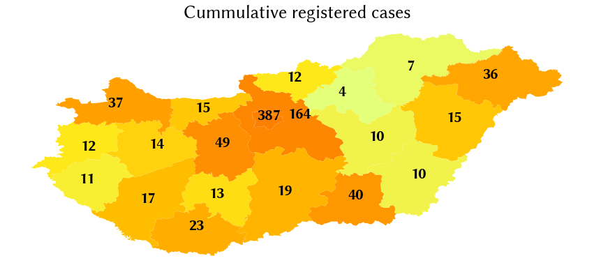

```python
fig, ax = plt.subplots(1, figsize=(15, 15))
ax = geodf.plot(column=today, cmap='Wistia', ax=ax)

for idx, row in geodf.iterrows():
    ax.annotate(s=row[today], xy=row['text_coord'],
                 horizontalalignment='center')

ax.set_title("Cummulative registered cases")
plt.axis("off")
plt.show()
```

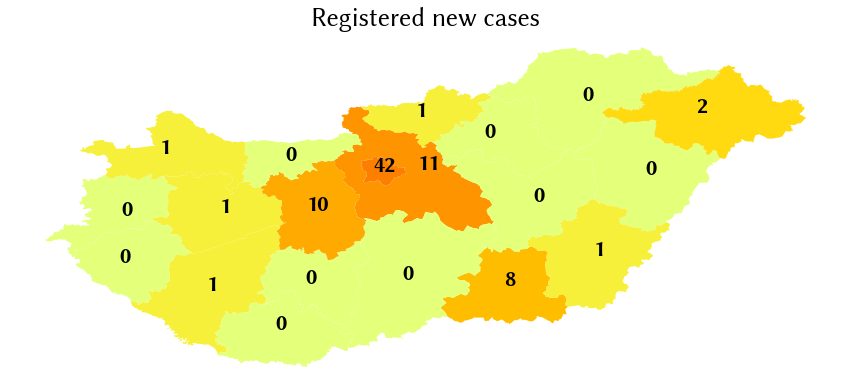

```python
fig, ax = plt.subplots(1, figsize=(15, 15))

geodf["difference"] = geodf[today] - geodf[yesterday]

ax = geodf.plot(column="difference", cmap='Wistia', ax=ax)

for idx, row in geodf.iterrows():
    ax.annotate(s=row["difference"], xy=row['text_coord'],
                 horizontalalignment='center')

ax.set_title("Registered new cases")
plt.axis("off")
plt.show()
```

```python
fig = go.Figure()

for i in range(dfc2.shape[1]):
    fig.add_trace(go.Scatter(
        x=dfc2.index,
        y=dfc2[dfc2.columns[i]],
        mode='lines+markers',
        marker=dict(
            symbol=i+1,
            size=10,
        ),
        name=dfc2.columns[i],
    ),)


fig.update_layout(
        title="Registered cases in the different counties",
        xaxis_title="Date",
        yaxis_title="Number of cases",
        font=dict(
            family="Linux Biolinum",
            size=18,
        ),
)
fig.show()
```

[interactive chart not shown]